# Lab1 Flotte Tunisair

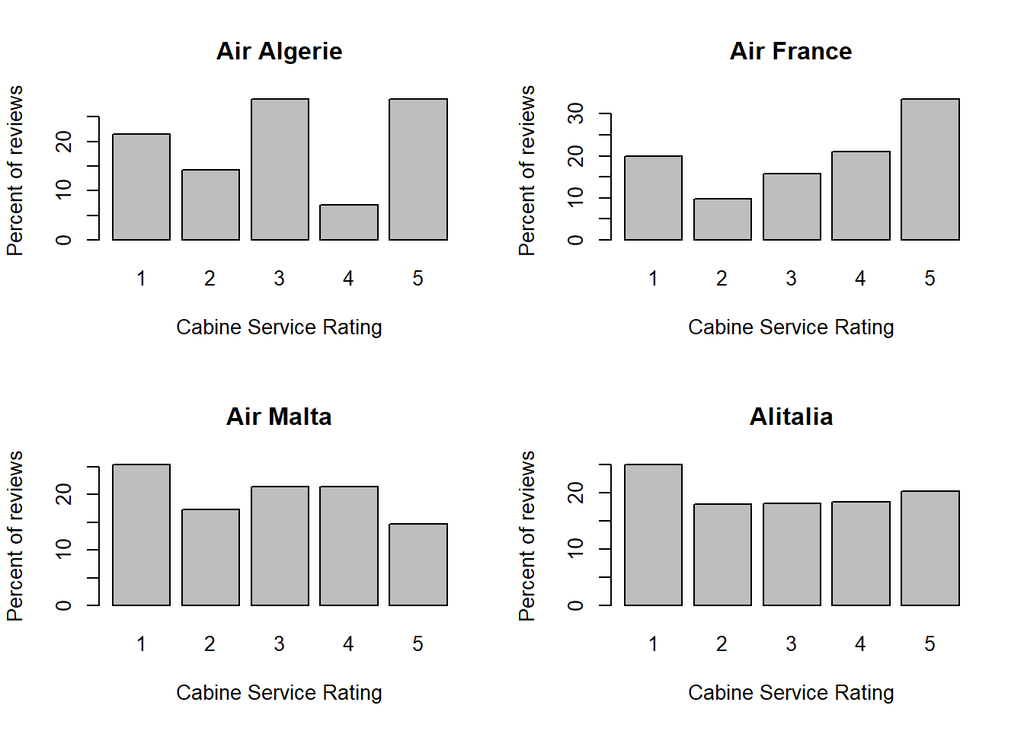

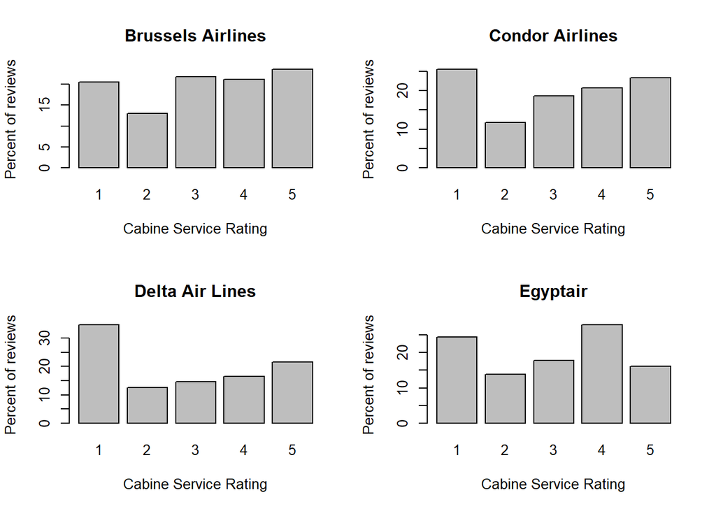

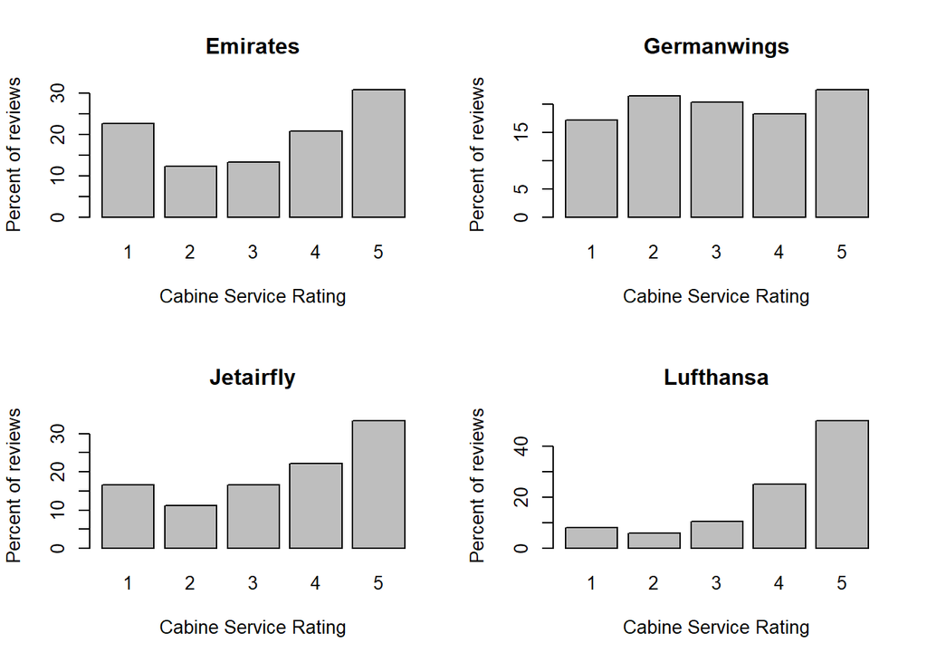

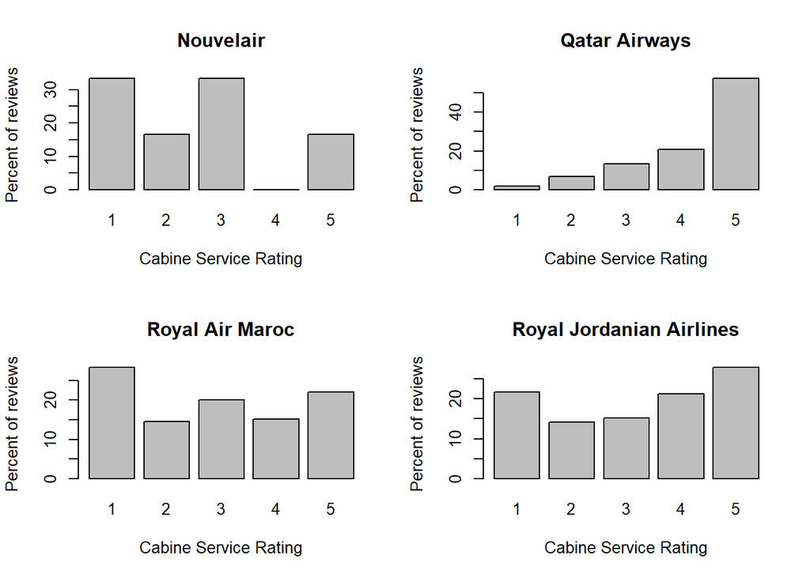

```r
for (i in aux){
  if(i!="http://www.airlinequality.com/airline-reviews/delta-air-lines/"){
  a=reviews[reviews$airline==i,]
  tab=table(a$cabin_service)
  tot=sum(tab)
  barplot(tab/tot*100,xlab="Cabine Service Rating",ylab = "Percent of reviews",main = a$airline[1])}
}
```

[figure not shown]

```r
aux=aux = levels(reviews$airline)
par(mfrow=c(2,2))
```

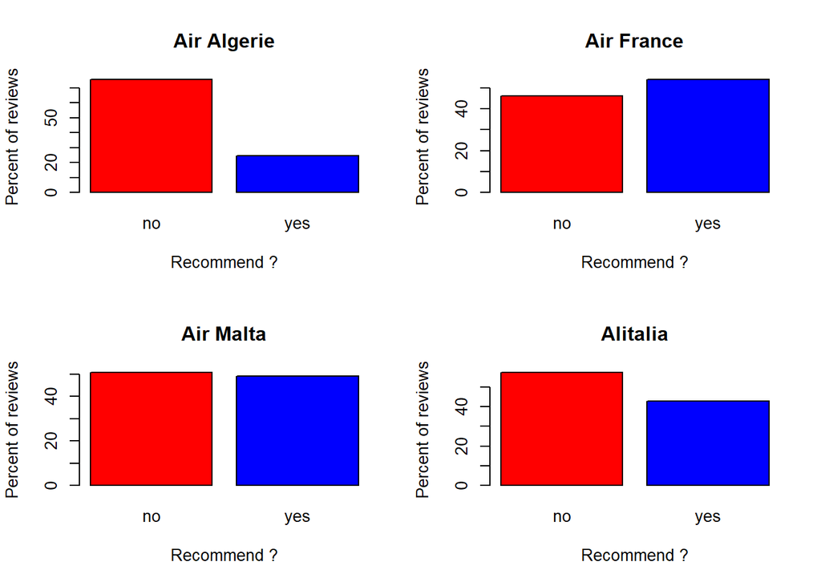

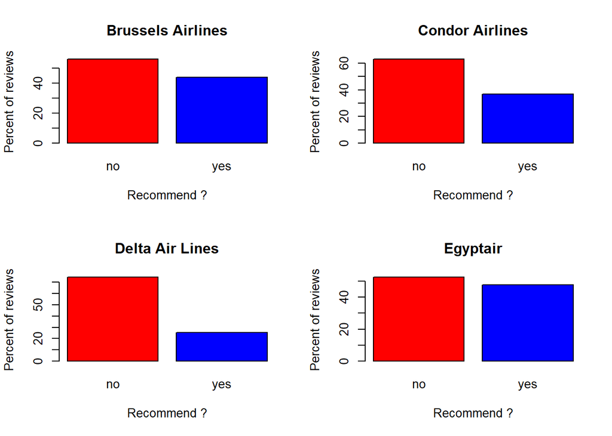

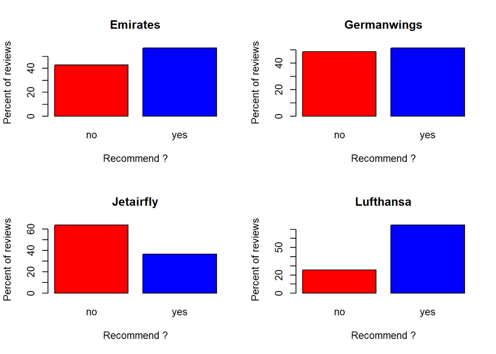

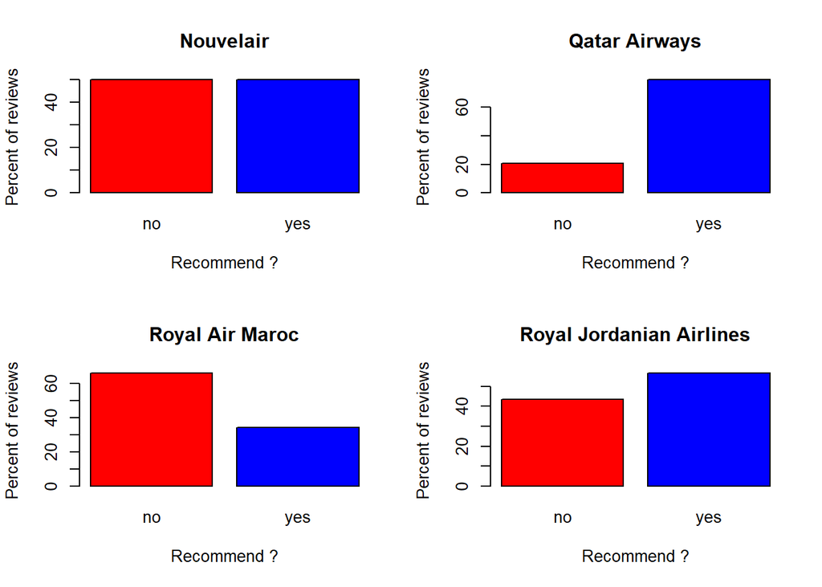

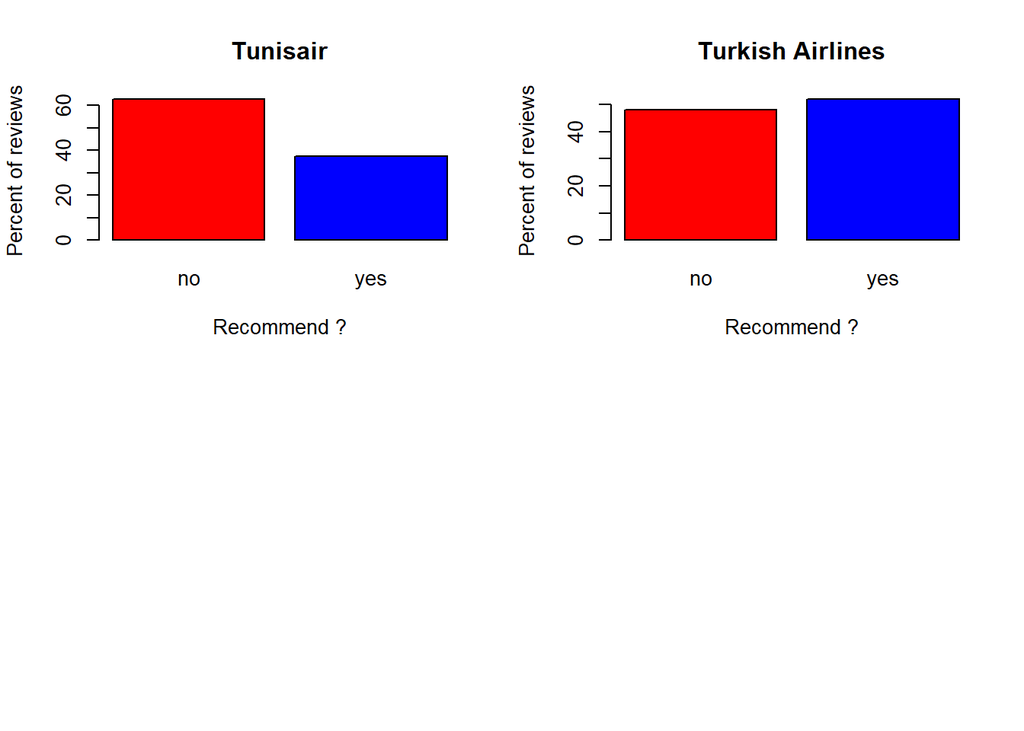

```r
for (i in aux){
  if(i!="http://www.airlinequality.com/airline-reviews/delta-air-lines/"){
  a=reviews[reviews$airline==i,]
  tab=table(a$recommended)
  tot=sum(tab)
  barplot(tab/tot*100,xlab="Recommend ?",ylab = "Percent of reviews",main = a$airline[1],col = c("red","blue"))}
}
```

## Flotte age , dimension et valeur:

```r
 db5
```

```
##                            ï..Airline Moy..Average.Age Current Future
## 1                             ABX Air            10.17      28      0
## 2                     Aegean Airlines             4.90      47      0
## 3                          Aer Lingus             4.45      51      1
## 4                 Aer Lingus Regional             4.80      11      0
## 5                            Aeroflot             1.13     189      2
## 6               Aerolineas Argentinas             4.40      54      2
## 7                          Aeromexico             2.56      69      2
## 8                  Aeromexico Connect            10.93      69      0
## 9                  Aeromexico Express             3.50       2      0
## 10                          AeroUnion            32.65       7      0
## 11                        Air Algerie             4.11      56      1
## 12                         Air Arabia             2.90      38      0
## 13                   Air Arabia Egypt             9.60       1      0
## 14                  Air Arabia Jordan            10.00       2      0
```

[output cut: 543 more lines]

```r
    dbquanti=db5[,-1]
na.fail(dbquanti)
```

```
##     Moy..Average.Age Current Future Moy..Total.Cost..Current.
## 1              10.17      28      0                   1744.33
## 2               4.90      47      0                    788.83
## 3               4.45      51      1                    489.77
## 4               4.80      11      0                    243.00
## 5               1.13     189      2                   1185.42
## 6               4.40      54      2                    774.63
## 7               2.56      69      2                    920.00
## 8              10.93      69      0                    859.00
## 9               3.50       2      0                     44.00
## 10             32.65       7      0                    374.50
## 11              4.11      56      1                    378.38
## 12              2.90      38      0                   3724.00
## 13              9.60       1      0                     98.00
## 14             10.00       2      0                    196.00
```

[output cut: 264 more lines]

```r
str(dbquanti)
```

```
## 'data.frame':    278 obs. of  4 variables:
##  $ Moy..Average.Age         : num  10.17 4.9 4.45 4.8 1.13 ...
##  $ Current                  : int  28 47 51 11 189 54 69 69 2 7 ...
##  $ Future                   : int  0 0 1 0 2 2 2 0 0 0 ...
##  $ Moy..Total.Cost..Current.: num  1744 789 490 243 1185 ...
```

```r
  gpe_kmeans2=kmeans(dbquanti,4)

  gpe_kmeans2
```

```
## K-means clustering with 4 clusters of sizes 46, 223, 1, 8
##
## Cluster means:
##   Moy..Average.Age   Current    Future Moy..Total.Cost..Current.
## 1         6.041522 186.13043  5.434783                 3057.3233
## 2         5.935157  41.80717  1.147982                  671.7031
## 3        11.700000 718.00000 38.000000                53118.0000
## 4         5.682500 253.62500 11.500000                 8282.7025
##
## Clustering vector:
##   [1] 2 2 2 2 2 2 2 2 2 2 2 1 2 2 2 2 2 2 2 2 2 2 1 1 2 2 2 2 1 2 2 2 2 2 2
##  [36] 2 2 2 2 2 2 2 2 2 2 2 2 2 2 2 2 1 2 2 1 2 1 2 2 2 1 1 2 2 2 2 2 2 2 2
##  [71] 2 2 2 2 2 2 2 1 2 2 2 1 4 2 2 1 2 1 1 2 2 1 2 2 1 2 2 1 2 1 2 2 2 2 2
## [106] 2 4 1 2 2 1 2 2 2 1 2 2 2 2 1 2 2 2 2 4 2 2 1 2 2 2 2 2 2 2 4 2 2 2 2
## [141] 2 2 1 2 2 2 2 4 2 2 2 2 1 2 2 2 1 2 2 1 1 2 2 2 2 2 2 2 1 2 2 2 2 2 2
## [176] 2 2 2 2 2 2 2 2 1 1 2 2 2 2 2 2 2 2 2 2 2 2 1 2 2 1 2 2 2 2 2 2 2 2 4
## [211] 2 1 2 2 2 1 2 1 2 2 2 1 2 3 2 2 4 2 2 2 2 2 2 2 1 2 2 2 1 2 2 2 2 2 2
## [246] 2 2 2 2 2 2 2 2 2 2 1 2 4 1 2 2 2 2 2 2 1 2 2 2 2 1 2 1 1 2 2 2 1
##
## Within cluster sum of squares by cluster:
## [1] 40144378 49497031        0 43652905
##  (between_SS / total_SS =  96.1 %)
##
## Available components:
##
## [1] "cluster"      "centers"      "totss"        "withinss"
## [5] "tot.withinss" "betweenss"    "size"         "iter"
## [9] "ifault"
```

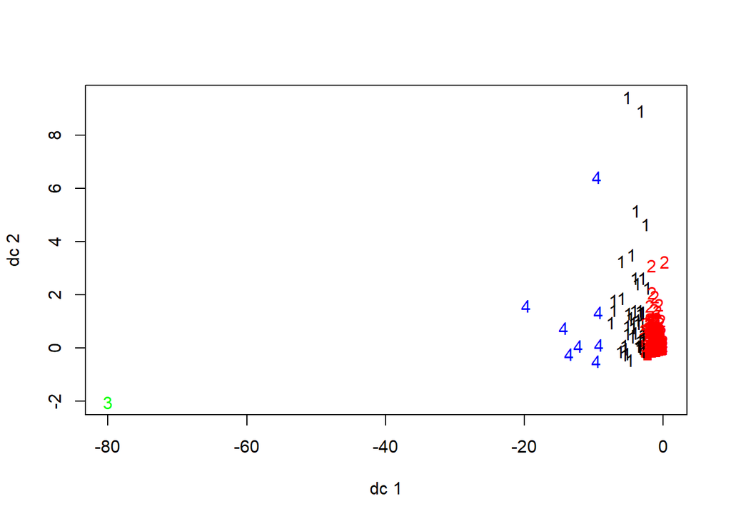

```r
library(fpc)
plotcluster(dbquanti, gpe_kmeans2$cluster)
```

On peut conclure que tunisair appartient a un profil qui a une flotte moyennement agées avec une petite flotte et des demandes trés faible dans le futur

## Analyse du profil typique des avions

### Application de k-means :

```r
k=kmeans(data1,5)
summary(k)
```

```
##              Length Class  Mode
## cluster      575    -none- numeric
## centers       30    -none- numeric
## totss          1    -none- numeric
## withinss       5    -none- numeric
## tot.withinss   1    -none- numeric
## betweenss      1    -none- numeric
## size           5    -none- numeric
## iter           1    -none- numeric
## ifault         1    -none- numeric
```

```r
k
```

```
## K-means clustering with 5 clusters of sizes 45, 116, 123, 215, 76
##
## Cluster means:
##   X..Engines Approach.Speed..Vref. Wingspan..ft Length..ft      MTOW
## 1   2.155556              60.26667    117.00000   98.71111  21.51111
## 2   2.896552             112.67241    256.20690  239.74138 121.85345
## 3   2.170732              71.86829    153.16260  155.26829 202.50407
## 4   3.046512             110.73488    226.35814  237.00465 425.77209
## 5   2.828947             122.20526     49.38158   59.25000 206.48684
##   Max.Ramp.Max.Taxi
## 1          16.71111
## 2          94.72414
## 3         259.48780
## 4         335.14419
## 5         154.98684
```

[output cut: 90 more lines]

Application de CAH :

```r
d=dist(data1,"euclidean")
hc=hclust(d, method="average")
hc
```

```
##
## Call:
## hclust(d = d, method = "average")
##
## Cluster method   : average
## Distance         : euclidean
## Number of objects: 575
```

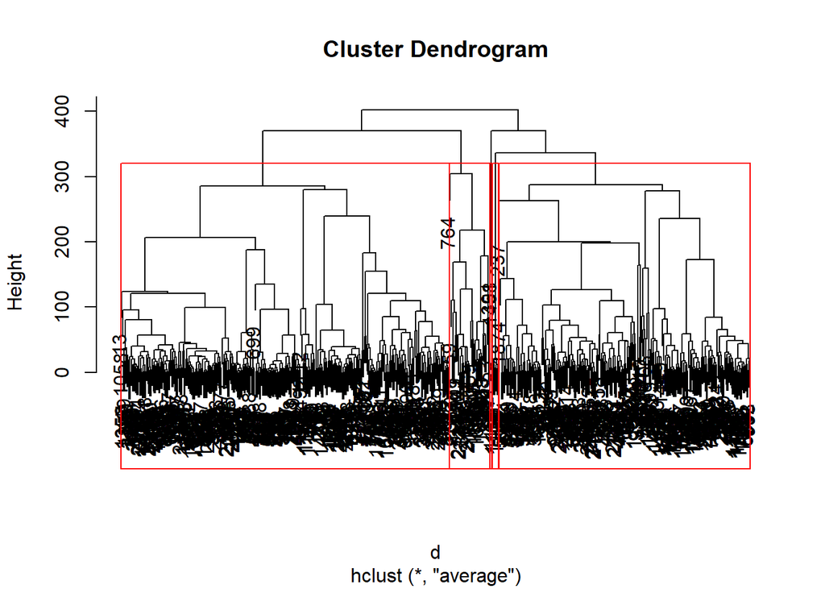

```r
plot(hc)
rect.hclust(hc, k=5)
```

# Déploiment

Pour conclure , nous pouvons assurer que Tunisair pourra augmenter ses parts de marché rien qu’en améliorant ces différents domaines (service , nourriture , confort) Elle pourra ainsi gagner de l’argent qu’elle pourrait investir dans l’achat de nouveaux avions. En effet, il y a des avions qui sont stockés dans des cimetières situés dans le désert californiens et en Arizona, alors Tunisair pourrait en acquérir à raison de 3 appareils pour le prix d’un appareil neuf de même catégorie. C’est l’une des solutions envisagées pour que Tunisair puisse tirer de juteux bénéfices